# COVID-19 and Religion

Sean McGoey

4/24/20

## Objective

Analyzing available data to determine if there are any possible links between particularly religious areas and COVID-19 cases. We know that COVID is highly transmissible from person to person, and religious services bring millions of people together across the country every week (or at least they used to – and they will again soon as states start to reopen). So let’s take a look at whether there’s any relationship.

## Setup

First, we’ll load our necessary packages.

```r
# Load tidyverse, tidycensus, janitor, scales, mapview, ggthemes
library(tidyverse)
library(tidycensus)
library(janitor)
library(scales)
library(mapview)
library(ggthemes)
```

Then we’ll load in county-level COVID-19 data from The New York Times and data from the Association of Religion Data Archives’ 2010 Religious Congregation Membership Study. (Ideally we’d have newer religion data than 2010, but the survey is conducted every 10 years.) We’ll also grab geodata from the census – we’ll use it to look at maps later.

```r
# Read in NYT county data, and build "key" column
nyt_covid_county <- read.csv("https://raw.githubusercontent.com/nytimes/covid-19-data/master/us-counties.csv") %>%
  mutate(key = paste(county, state, sep = "|", collapse=NULL))

# Read in 2010 Religion Census data
rcms_religion_data <- read.csv("data/rcms_2010.csv") %>%
  clean_names() %>%
  rename(congregations_per_10k = congregations_per_10k_people)

# Define Census API Key
census_api_key("549950d36c22ff16455fe196bbbd01d63cfbe6cf")

# Load ACS variable definitions
acs_variables <- load_variables(2017, "acs5" )

# Pull in shifted geodata
county_geodata_shifted <- get_acs(geography = "county",
              variables = c("B01001_001"), geometry = TRUE, shift_geo = TRUE)
```

Next, because the NYT data is a cumulative set – tracking the total number of cases/deaths every day rather than each day’s new count – we’ll pull out only the highest values to find the most updated totals.

```r
# Group by key phrase in order to examine each county's case count peak to date
nyt_covid_county_max <- nyt_covid_county %>%
  filter(!is.na(fips)) %>%
  filter(!str_detect(county, "Unknown")) %>%
  group_by(key, county, state, fips) %>%
  summarise(case_peak = max(cases))
```

Then we’ll join the table of max case counts to the religion census data and add a column for cases per 10K population.

```r
county_covid_religion <- inner_join(nyt_covid_county_max, rcms_religion_data, BY=key) %>%
  select(key, fips, county, state, population, adherents, congregations, congregations_per_10k, religious_adherence, case_peak) %>%
  mutate(cases_per_10k = case_peak / population * 10000) %>%
  mutate(fips = toString(fips)) %>%
  mutate(fips = if_else(str_length(fips) == 4, paste("0", fips, sep="", collapse = NULL), fips))

# NOTE: Mutate functions convert fips from an int to a string and solves for leading 0s being omitted when formatted as numbers.
```

We’ll also build a table that allows us to look at variables on the map.

```r
geo_county_covid_religion <- county_geodata_shifted %>%
 inner_join(county_covid_religion, by=c("GEOID" = "fips"))
```

## First variable: Religious adherence

We’re going to start by looking at the relationship between religious adherence and confirmed cases so far. Let’s plot out some maps. First, per-capita COVID cases in each county across the country:

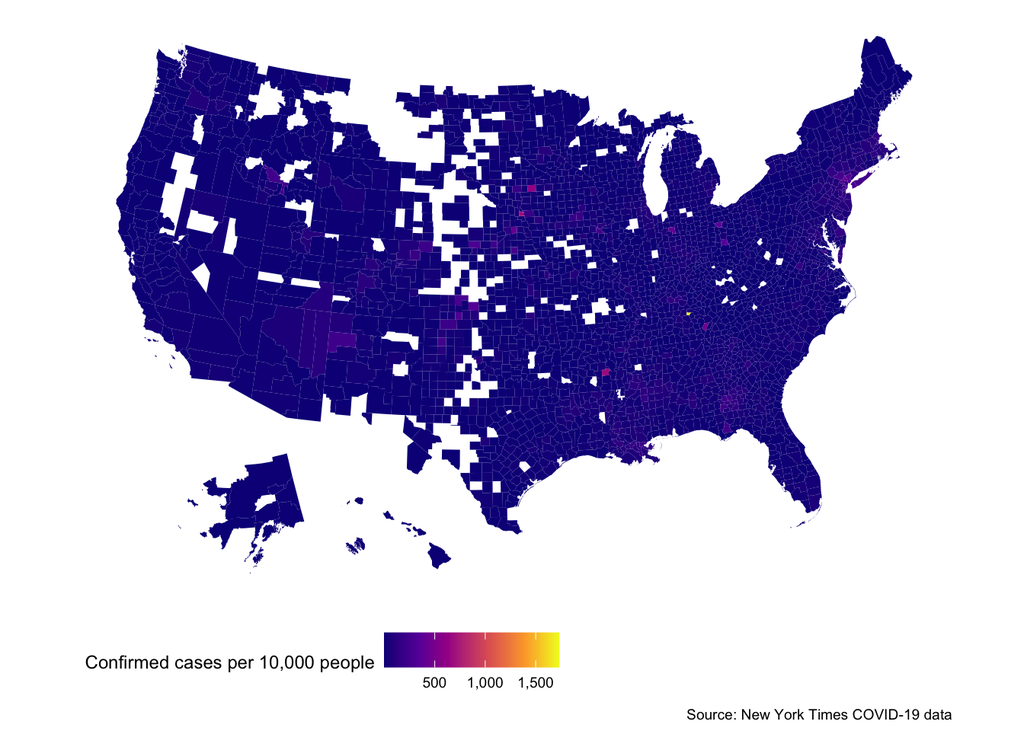

```r
geo_county_covid_religion %>%
  ggplot(aes(fill = cases_per_10k)) +
  geom_sf(lwd = 0) +
  theme_map() +
  labs(fill='Confirmed cases per 10,000 people', caption = "Source: New York Times COVID-19 data") +
  scale_fill_continuous(labels = comma) +
  theme(legend.position="bottom") +
  scale_fill_viridis_c(option = "plasma",labels = comma)
```

A few well-defined hot spots around the country, but not necessarily much in the way of a pattern. Next, we’ll look at religious adherence:

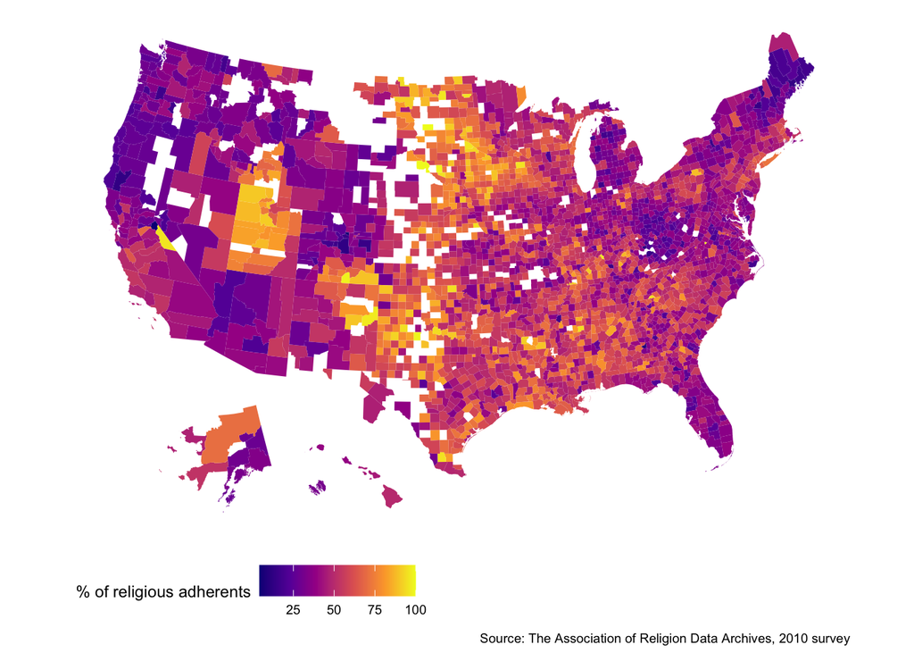

```r
geo_county_covid_religion %>%
  ggplot(aes(fill = religious_adherence)) +
  geom_sf(lwd = 0) +
  theme_map() +
  labs(fill='% of religious adherents',caption = "Source: The Association of Religion Data Archives, 2010 survey") +
  scale_fill_continuous(labels = comma) +
  theme(legend.position="bottom") +
  scale_fill_viridis_c(option = "plasma",labels = comma)
```

That’s a much more defined pattern: Lots of adherents in the South, Midwest and Plains states, with a few other pockets around the country.

But we need more than just maps. Let’s see if we can find an actual relationship between religious adherence and COVID cases so far.

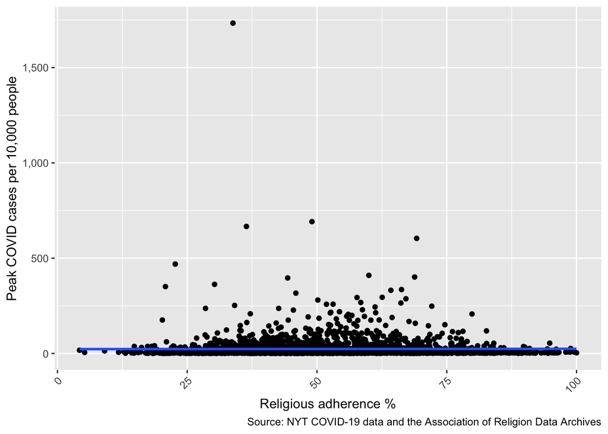

```r
ggplot(county_covid_religion) +
  geom_point(aes(religious_adherence, cases_per_10k)) +
  labs(x="Religious adherence %", y="Peak COVID cases per 10,000 people", caption = "Source: NYT COVID-19 data and the Association of Religion Data Archives", fill="key") +
  scale_y_continuous(labels = comma) +
  scale_x_continuous(labels = comma) +
  theme(axis.text.x = element_text(angle = 45, hjust = 1)) +
  geom_smooth(aes(religious_adherence, cases_per_10k), method = "lm", se = FALSE)
```

It doesn’t look like there’s much of a relationship; we can check that with a correlation test.

```r
# Test the relationship
correlation_covid_adherents <- county_covid_religion %>%
  ungroup() %>%
  select(religious_adherence, cases_per_10k)

cor.test(correlation_covid_adherents$religious_adherence, correlation_covid_adherents$cases_per_10k)
```

```
##
##  Pearson's product-moment correlation
##
## data:  correlation_covid_adherents$religious_adherence and correlation_covid_adherents$cases_per_10k
## t = 0.24852, df = 2852, p-value = 0.8038
## alternative hypothesis: true correlation is not equal to 0
## 95 percent confidence interval:
##  -0.03204252  0.04133703
## sample estimates:
##        cor
## 0.00465352
```

Okay, so there’s really nothing there to suggest that there’s a link between the most religious counties in the U.S. and the cases of COVID-19 that have been confirmed so far. That makes some sense: according to mobile location tracking data from SafeGraph, church attendance is down an average of 76% nationwide since the first week of March, so places of worship have had limited opportunity to be spreading grounds.

## Second variable: Concentration of religious adherents

What about another measure: not just the number of people who are adherents in a given county, but the *concentration* of those adherents? The ARDA data set includes a figure for congregations per 10,000 residents, which would help us assess whether areas with many different churches are more likely to have seen COVID outbreaks.

As we did with adherents, let’s start with the maps. A quick reminder of the distribution of COVID cases:

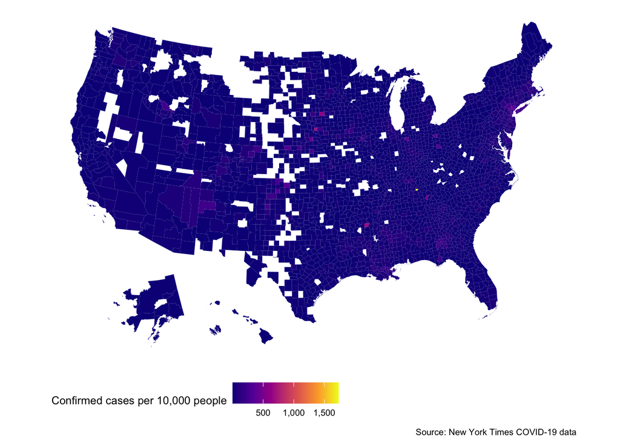

```r
geo_county_covid_religion %>%
  ggplot(aes(fill = cases_per_10k)) +
  geom_sf(lwd = 0) +
  theme_map() +
  labs(fill='Confirmed cases per 10,000 people', caption = "Source: New York Times COVID-19 data") +
  scale_fill_continuous(labels = comma) +
  theme(legend.position="bottom") +
  scale_fill_viridis_c(option = "plasma",labels = comma)
```

And now we’ll map out congregations per 10,000 residents:

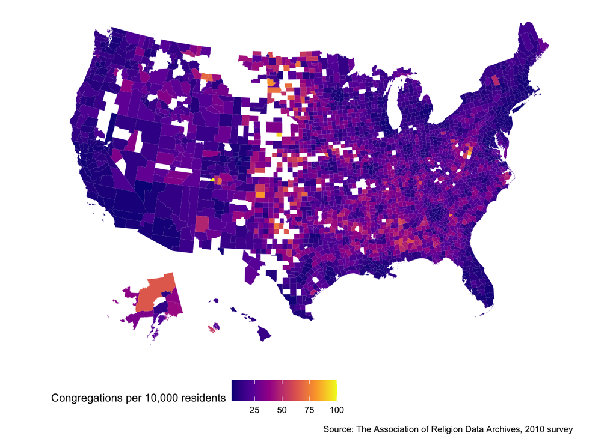

```r
geo_county_covid_religion %>%
  ggplot(aes(fill = congregations_per_10k)) +
  geom_sf(lwd = 0) +
  theme_map() +
  labs(fill='Congregations per 10,000 residents',caption = "Source: The Association of Religion Data Archives, 2010 survey") +
  scale_fill_continuous(labels = comma) +
  theme(legend.position="bottom") +
  scale_fill_viridis_c(option = "plasma",labels = comma)
```

Still more congregations per 10K in the South/Plains areas – fewer on the coasts and in major population centers.

Now we’re going to plot congregations per 10,000 against peak confirmed cases per 10,000.

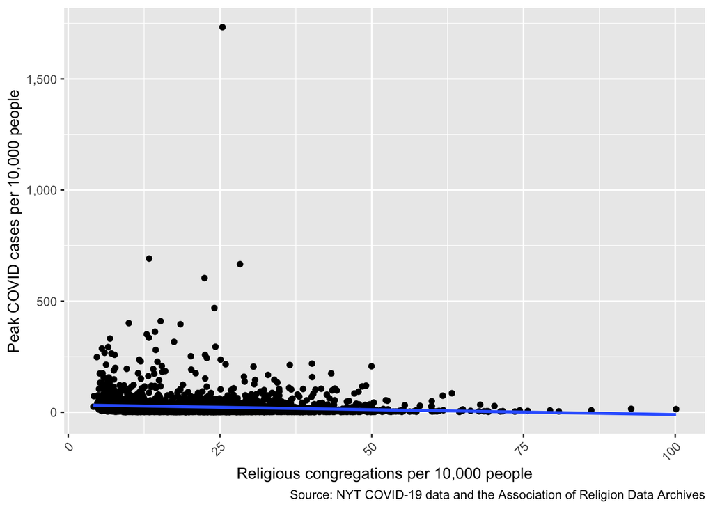

```r
ggplot(county_covid_religion) +
  geom_point(aes(congregations_per_10k, cases_per_10k)) +
  labs(x="Religious congregations per 10,000 people", y="Peak COVID cases per 10,000 people", caption = "Source: NYT COVID-19 data and the Association of Religion Data Archives", fill="key") +
  scale_y_continuous(labels = comma) +
  scale_x_continuous(labels = comma) +
  theme(axis.text.x = element_text(angle = 45, hjust = 1)) +
  geom_smooth(aes(congregations_per_10k, cases_per_10k), method = "lm", se = FALSE)
```

We can see a clearer pattern here than with the adherents – it’s looking like there are actually higher COVID instances in counties with fewer congregations. Let’s test the relationship:

```r
# Test the relationship
correlation_covid_religion <- county_covid_religion %>%
  ungroup() %>%
  select(congregations_per_10k, cases_per_10k)

cor.test(correlation_covid_religion$congregations_per_10k, correlation_covid_religion$cases_per_10k)
```

```
##
##  Pearson's product-moment correlation
##
## data:  correlation_covid_religion$congregations_per_10k and correlation_covid_religion$cases_per_10k
## t = -5.1543, df = 2852, p-value = 2.72e-07
## alternative hypothesis: true correlation is not equal to 0
## 95 percent confidence interval:
##  -0.13229271 -0.05958791
## sample estimates:
##         cor
## -0.09606844
```

So it’s not a strong correlation, but it is statistically significant. Counties where there are fewer congregations per 10,000 residents are slightly more likely to have already experienced coronavirus outbreaks. That makes some sense; fewer congregations means that the religious adherents in a given county are more concentrated into the same worship spaces.

## Looking to the future

So maybe there’s not a large correlation between religious adherence or congregations per 10,000 residents and confirmed COVID-19 cases to date. But that also makes some sense; as [The Washington Post reported](https://www.washingtonpost.com/religion/2020/04/17/cell-phone-data-coronavirus-churchgoers-home-easter/), mobile location data shows that stay-at-home orders were actually pretty effective at keeping churchgoers home on Easter – one of the biggest attendance days of the year for Christian churches. But some states are starting to lift their stay-at-home orders, so is it possible that some counties could be vulnerable to new outbreaks once people start to return to churches?

Let’s start by using what we’ve already looked at to identify a subset of counties: ones with high rates of religious adherence and lower numbers of congregations per 10,000 residents. How many of the ~2,800 counties in our current dataset are in the top 20% of religious adherents and the bottom 20% of congregations per 10K?

```r
high_adherence_low_congregation <- county_covid_religion %>%
  filter(religious_adherence >= quantile(county_covid_religion$religious_adherence, probs = 0.80)) %>%
  filter(congregations_per_10k <= quantile(county_covid_religion$congregations_per_10k, probs = 0.20)) %>%
  select(fips, county, state, population, religious_adherence, congregations_per_10k, key) %>%
  arrange(desc(population))

high_adherence_low_congregation
```

```
## # A tibble: 32 x 7
## # Groups:   key, county, state [32]
##    fips  county   state   population religious_adhere… congregations_p… key
##    <chr> <chr>    <chr>        <int>             <dbl>            <dbl> <chr>
##  1 36103 Suffolk  New Yo…    1493350              72.1             4.71 Suffolk…
##  2 36059 Nassau   New Yo…    1339532              67.1             5.55 Nassau|…
##  3 13121 Fulton   Georgia     920581              65.8             8.2  Fulton|…
##  4 17043 DuPage   Illino…     916924              71.6             5.69 DuPage|…
##  5 25021 Norfolk  Massac…     670850              64.7             5.07 Norfolk…
##  6 42017 Bucks    Pennsy…     625249              68.8             6.3  Bucks|P…
##  7 34039 Union    New Je…     536499              66.2             7.12 Union|N…
##  8 22033 East Ba… Louisi…     440171              67.5             9.91 East Ba…
##  9 36087 Rockland New Yo…     311687              68.8             9.98 Rocklan…
## 10 18141 St. Jos… Indiana     266931              65.5            10.2  St. Jos…
## # … with 22 more rows
```

But which of these areas could be vulnerable as the hot spots of the *future*? Let’s see what happens when we limit that list to places that are not already among the counties with the highest rates of COVID-19 cases:

```r
high_adherence_low_congregation <- county_covid_religion %>%
  filter(religious_adherence >= quantile(county_covid_religion$religious_adherence, probs = 0.80)) %>%
  filter(congregations_per_10k <= quantile(county_covid_religion$congregations_per_10k, probs = 0.20)) %>%
  filter(cases_per_10k <= quantile(county_covid_religion$cases_per_10k, probs = 0.85)) %>%
  mutate(avg_congregation_size = population / congregations) %>%
  select(county, state, population, religious_adherence, congregations, avg_congregation_size, congregations_per_10k, fips, key) %>%
  arrange(congregations_per_10k)

high_adherence_low_congregation
```

```
## # A tibble: 15 x 9
## # Groups:   key, county, state [15]
##    county state population religious_adher… congregations avg_congregatio…
##    <chr>  <chr>      <int>            <dbl>         <int>            <dbl>
##  1 Brist… Rhod…      49875             83.5            25            1995
##  2 San B… Cali…      55269             64.6            32            1727.
##  3 Lafay… Loui…     221578             76.5           136            1629.
##  4 Outag… Wisc…     176695             73.1           139            1271.
##  5 Rockw… Texas      78337             81.9            73            1073.
##  6 Menom… Wisc…       4232             70.7             4            1058
##  7 Dubuq… Iowa       93653             68.4            91            1029.
##  8 Manit… Wisc…      81442             71.0            81            1005.
##  9 St. J… Indi…     266931             65.5           273             978.
## 10 Midla… Texas     136872             71.5           148             925.
## 11 Fayet… Geor…     106567             66             117             911.
## 12 Marat… Wisc…     134063             64.9           149             900.
## 13 Kewau… Wisc…      20574             70.6            23             895.
## 14 Mono   Cali…      14202             96.1            16             888.
## 15 St. L… Loui…      83384             70.9            95             878.
## # … with 3 more variables: congregations_per_10k <dbl>, fips <chr>, key <chr>
```

Again, there a couple of interesting findings, like Bristol County, RI, which is a heavily Catholic county with an average congregation size of nearly 2,000 people. But it still might not be the best story.

## Untangling COVID’s racial disparities

We know from [data provided by the CDC](https://www.cdc.gov/coronavirus/2019-ncov/need-extra-precautions/racial-ethnic-minorities.html) that COVID-19 has disproportionately affected black communities, both in terms of confirmed cases and deaths. Let’s try some of this analysis again, but with a focus on heavily African American counties. We need to start by identifying those counties. At the 2010 census, 12.6% of the U.S. population reported as Black or African American, so let’s use double that number – 25% and up – as a guidepost.

```r
# Pull in African American population at county level
county_geodata_aa <- get_acs(geography = "county",
              variables = "B02001_003", geometry = TRUE) %>%
  rename(aa_pop=estimate)
# Join African American population to county table, filter on % African American >= 25
county_covid_religion_aa <- county_covid_religion %>%
  inner_join(county_geodata_aa, by=c("fips" = "GEOID")) %>%
  mutate(aa_percentage = aa_pop/population) %>%
  filter(aa_percentage >= .25)
```

Is there a stronger relationship between religious adherence and COVID cases in heavily African American counties?

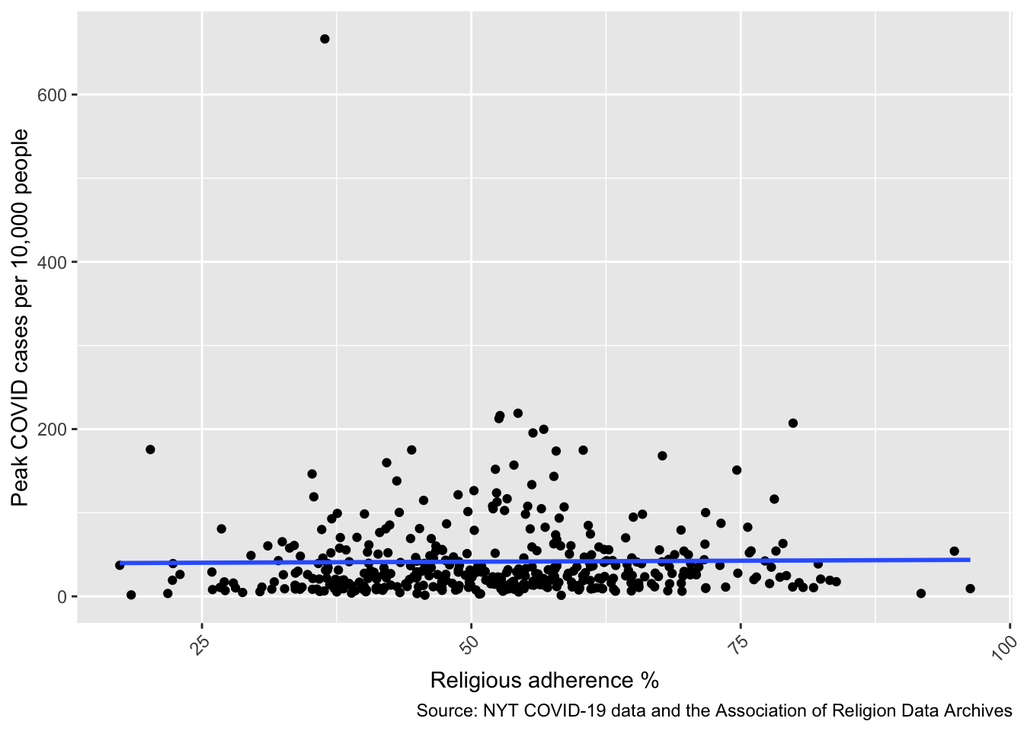

```r
ggplot(county_covid_religion_aa) +
  geom_point(aes(religious_adherence, cases_per_10k)) +
  labs(x="Religious adherence %", y="Peak COVID cases per 10,000 people", caption = "Source: NYT COVID-19 data and the Association of Religion Data Archives", fill="key") +
  scale_y_continuous(labels = comma) +
  scale_x_continuous(labels = comma) +
  theme(axis.text.x = element_text(angle = 45, hjust = 1)) +
  geom_smooth(aes(religious_adherence, cases_per_10k), method = "lm", se = FALSE)
```

And we’ll test the correlation.

```r
# Test the relationship
correlation_covid_adherents_aa <- county_covid_religion_aa %>%
  select(religious_adherence, cases_per_10k)

cor.test(correlation_covid_adherents_aa$religious_adherence, correlation_covid_adherents_aa$cases_per_10k)
```

```
##
##  Pearson's product-moment correlation
##
## data:  correlation_covid_adherents_aa$religious_adherence and correlation_covid_adherents_aa$cases_per_10k
## t = 0.26568, df = 405, p-value = 0.7906
## alternative hypothesis: true correlation is not equal to 0
## 95 percent confidence interval:
##  -0.08411123  0.11026312
## sample estimates:
##        cor
## 0.01320065
```

So there’s still no serious connection between adherence and COVID in heavily African American counties. Let’s check on the relationship between congregations per 10,000 and COVID.

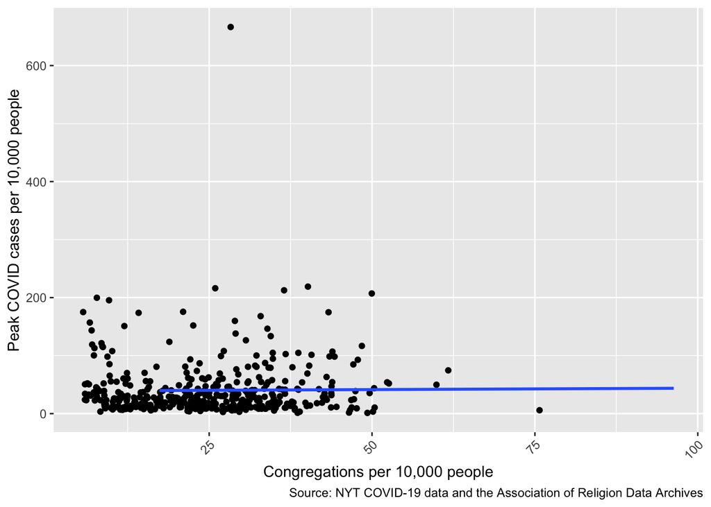

```r
ggplot(county_covid_religion_aa) +
  geom_point(aes(congregations_per_10k, cases_per_10k)) +
  labs(x="Congregations per 10,000 people", y="Peak COVID cases per 10,000 people", caption = "Source: NYT COVID-19 data and the Association of Religion Data Archives", fill="key") +
  scale_y_continuous(labels = comma) +
  scale_x_continuous(labels = comma) +
  theme(axis.text.x = element_text(angle = 45, hjust = 1)) +
  geom_smooth(aes(religious_adherence, cases_per_10k), method = "lm", se = FALSE)
```

And we’ll test the correlation.

```r
# Test the relationship
correlation_covid_congregations_aa <- county_covid_religion_aa %>%
  select(congregations_per_10k, cases_per_10k)

cor.test(correlation_covid_congregations_aa$congregations_per_10k, correlation_covid_congregations_aa$cases_per_10k)
```

```
##
##  Pearson's product-moment correlation
##
## data:  correlation_covid_congregations_aa$congregations_per_10k and correlation_covid_congregations_aa$cases_per_10k
## t = 0.45856, df = 405, p-value = 0.6468
## alternative hypothesis: true correlation is not equal to 0
## 95 percent confidence interval:
##  -0.07458885  0.11971913
## sample estimates:
##        cor
## 0.02278027
```